# Sosiaalisen median aktiivikäyttö ja syntyvyys

Antti J. Tanskanen, Elinkeinoelämän keskusliitto EK

1.3.2023

## Aineisto

Tutkimuksessa käytetty aikasarja-aineisto on peräisin tilastokeskuksen StatFin-tietokannasta ja Human Mortality Databasesta. Aineisto koostuu vuosien 1989-2017 datasta. Väestörakenteesta (Tilastokeskus) mukana on syntyneidet lukumäärät, kokonaishedelmällisyysluvut, synnyttäjien keski-ikä ja naisten lukumäärät 5-vuotisikäryhmittäin. Mukana ovat myös avioliittojen määrät 10-vuotisikäluokittain suhteutettuna ikäluokkien suuruuteen (Tilastokeskus).

Työllisyyttä (Tilastokeskus) kuvataan 10-vuotisikäluokittaisilla työllisyysasteilla sukupuolittain, 10-vuotisikäluokkakohtaisista työttömyysasteista sukupuolittain (suhteutettu ikäluokan kokoon, ), ja työsuhteiden tyyppitiedoilla (jatkuva/määräaikainen; kokoaikainen/osa-aikainen) vuosilta 1997-2017. Kaupungistumista kuvaa sisemmässä kaupungissa, ulommassa kaupungissa ja kehyskaupungissa asuvien osuudet väestöstä (Tilastokeskus)

Verrattuna aiempiin harjoitelmiin, mukaan on otettu myös sosiaalisen median aktiivikäyttäjien osuus Tilastokeskuksen Viestintä- ja tietotekniikan käyttö-tutkimuksesta (“Seuraa jotain yhteisöpalvelua yleensä jatkuvasti kirjautuneena tai useasti päivässä”).

Kaikkiaan lähtöaineistossa on 53 aikasarjaa, joissa on 29 havaintoa vuosilta 1989-2017, tosin osasta aikasarjoja vuosien 1989 ja/tai 2017 luvut puuttuvat. Kaikkia aineistossa olevia muuttujia ei ole tutkimuksessa käytetty, vaan keskitytty kokeiluissa lupaavimpiin 9:ään muuttujiin.

Aineiston perusteella ei voi tehdä kausaalisia päätelmiä, ainostaan assosiatiivisuutta koskevia. Tämä tietenkin rajoittaa tulkintamahdollisuuksia.

Tarkoituksena on avoimen, toistettavan tutkimuksen hengessä näyttää täsmällisesti mitä on tehty. Tästä syystä alkuperäinen aineisto (myös tämä työkirja koodeineen, Rmd-muotoisena; data Rdata-muodossa) on kokonaisuudessaan saatavissa osoitteesta https://github.com/ajtanskanen/Syntyvyyden-tekij-t

Miten aineiston arviointi onnistui?

Mallin ennuste 2018 kerätyn datan (aineisto 2017 ja aiemmin) perusteella vuodelle 2022 oli 1,326819, kun toteuma oli 1,31. Ennuste oli melko hyvä jälkeenpäin arvioituna. Lineaarisesti kokonaishedelmällisyysluvun trendiä jatkamalla tulos olisi ollut 1,09 (1v trendimuutos) tai 1,19 (5v trendimuutos), joka olisi ollut merkittävästi huonompi tulos.

## Vanha ennuste uudella datalla 2023

```
## # A tibble: 41 × 80
##    vuosi syntyneita hedelmallisyysluku tyollisyysaste_miehet_15_24
##    <dbl>      <dbl>              <dbl>                       <dbl>
##  1  1990      65549               1.79                        52
##  2  1991      65395               1.8                         43
##  3  1992      66731               1.85                        33.9
##  4  1993      64826               1.81                        29.3
##  5  1994      65231               1.85                        27.3
##  6  1995      63067               1.81                        29.9
##  7  1996      60723               1.76                        30.2
##  8  1997      59329               1.75                        34
##  9  1998      57108               1.71                        36.1
## 10  1999      57574               1.73                        39.3
## # ℹ 31 more rows
## # ℹ 76 more variables: tyollisyysaste_naiset_15_24 <dbl>,
## #   naisten_lkm_15_19 <dbl>, naisten_lkm_20_24 <dbl>, naisten_lkm_25_29 <dbl>,
## #   naisten_lkm_30_34 <dbl>, naisten_lkm_35_39 <dbl>, naisten_lkm_40_45 <dbl>,
## #   naisten_lkm_45_49 <dbl>, naisten_lkm_15_49 <dbl>, naisten_lkm_24_39 <dbl>,
## #   pienituloisuus_0_17 <dbl>, pienituloisuus_18_24 <dbl>,
## #   pienituloisuus_25_34 <dbl>, pienituloisuus_35_49 <dbl>, …
```

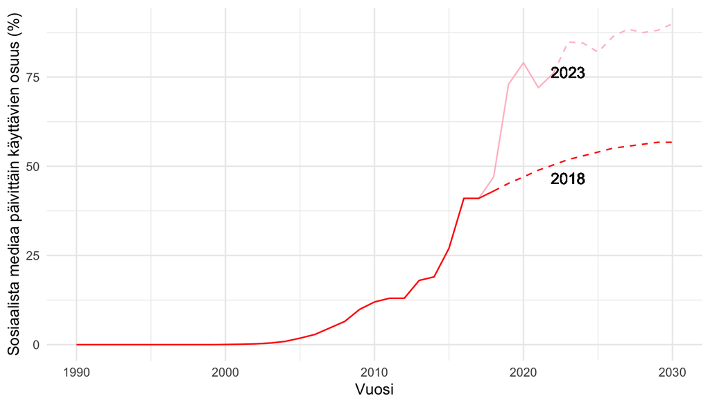

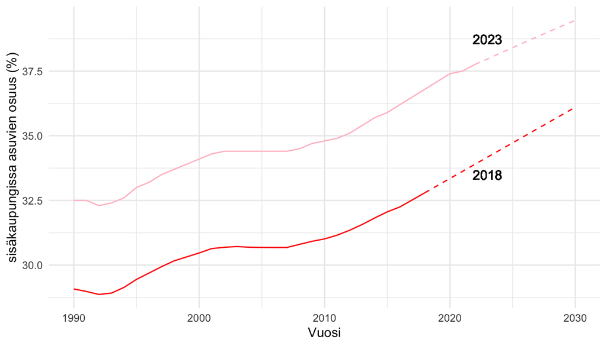

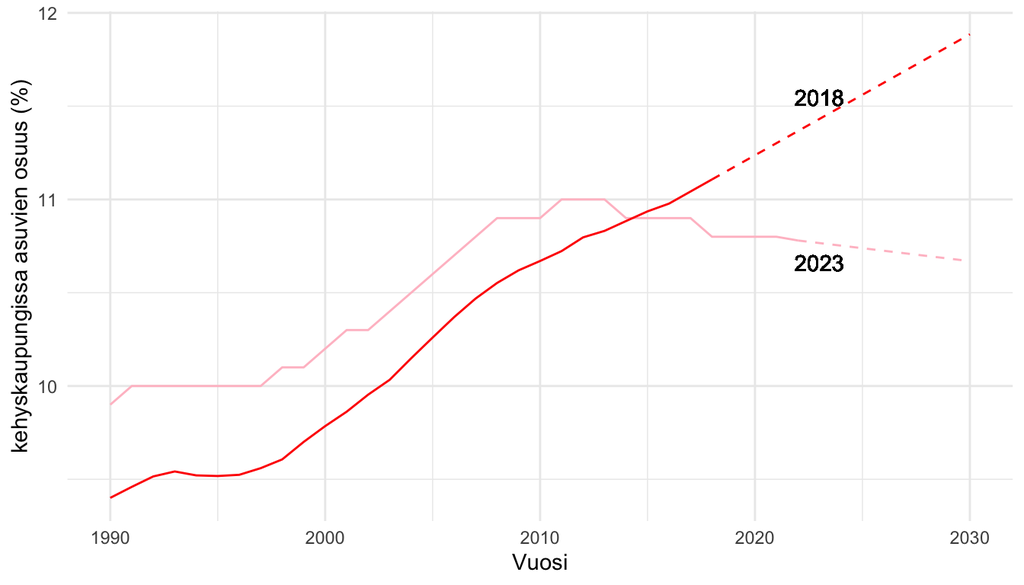

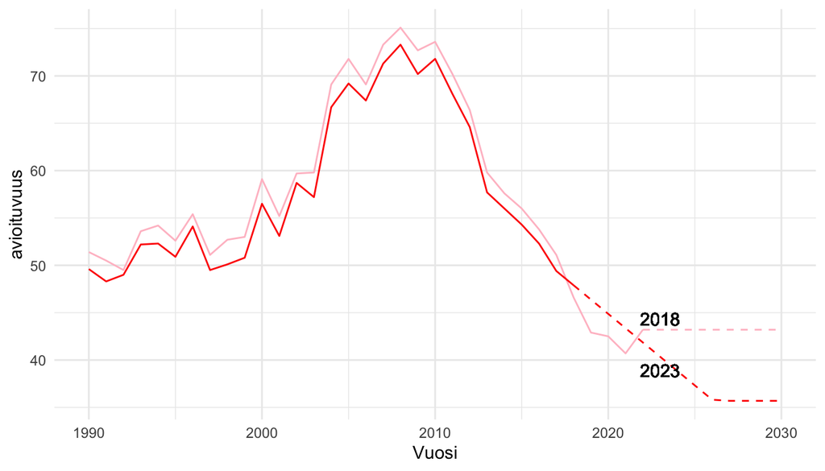

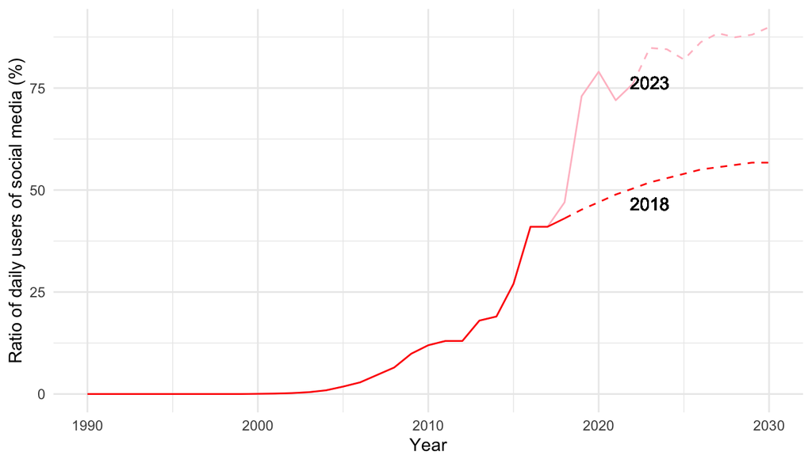

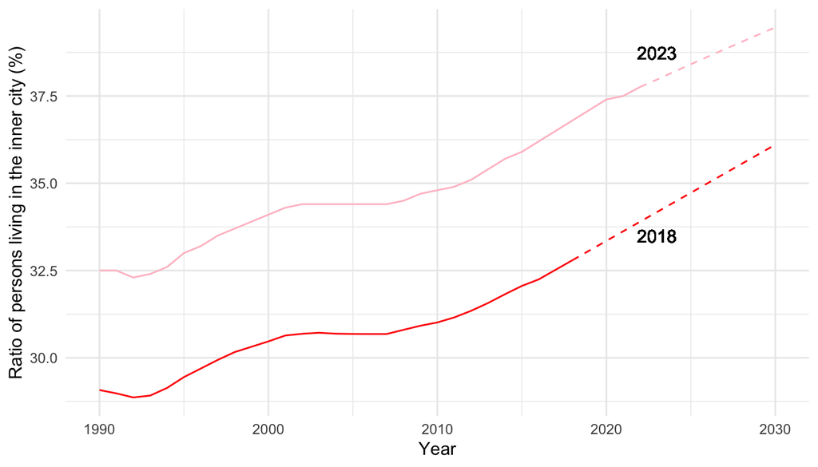

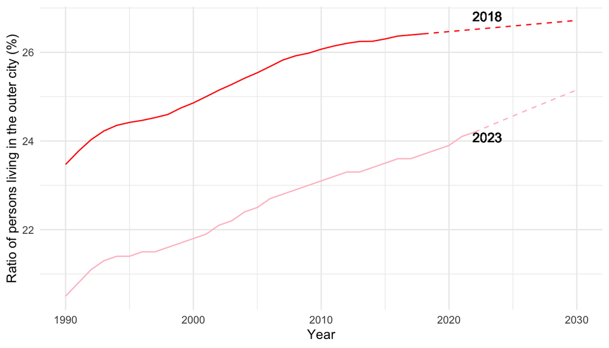

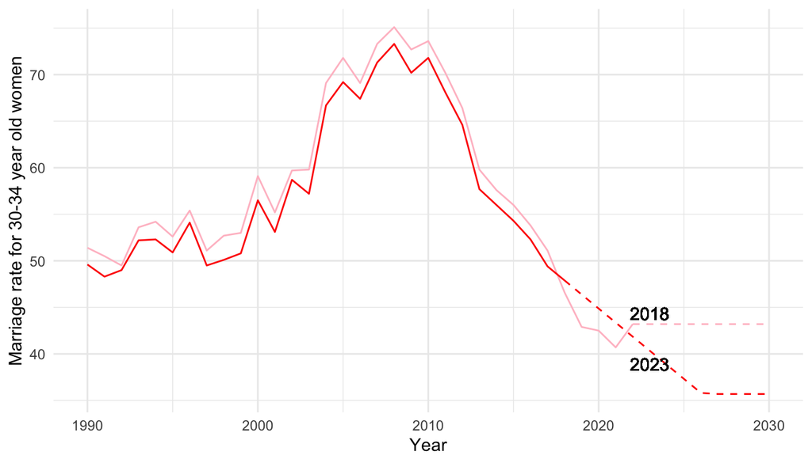

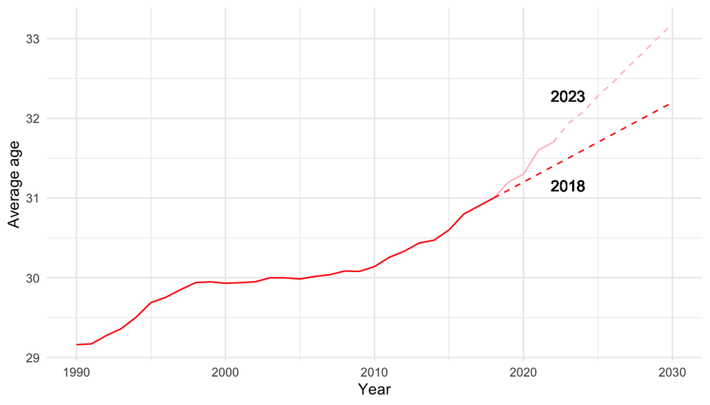

## Syntyvyyden laskun syyt

Vaikka tällä tutkimuksella ei pääse kiinni syntyvyyden laskun kausaalisiin syihin, näkyy tuloksista selvästi, että syntyvyyden laskua ajaa kaksi erilaista tekijää: hedelmällisyysluvun lasku ja synnytysikäisten naisten lukumäärän lasku. Vaikeampaa on yrittää selittää, mistä hedelmällisyysluvun lasku johtuu.

Sisäkaupungissa asuvien osuuden kasvu kytkeytyi tässä tutkimuksessa synnyttäneiden keski-iän nousuun. Tilastokeskuksen tiedoista tiedetään, että kaupungeissa syntyvyys on alempaa kuin muussa maassa: “Vastaavasti matalin syntyvyys oli jaksolla 2013–2017 Helsingissä, jossa kokonaishedelmällisyysluku oli 1,27. Turussa luku oli 1,29 ja Tampereella 1,34. Myös kaikkien kuntien vertailussa viimeksi mainittujen kaupunkien syntyvyys oli matalimpien joukossa.” (Tilastokeskus, väestörakenne 2018). Uudemmat tiedot ovat vielä matalampi: Helsingissä kokonaishedelmällisyysluku on noin 1,10 vuonna 2019.

Suurin osa lapsiperheistä on edelleen avioperheitä. Avioituvuus erityisesti 30-34-vuotiailla kytkeytyy selvästi syntyneiden lasten määrään. Ainakin aiemmin on argumentoitu, että verrattuna avoliittoihin, avioliitoissa syntyy enemmän lapsia. Kyse voi olla myös valinnasta, mutta osaltaan avioituvuuden aleneminen kertoo asenne- tai preferenssimuutoksesta.

Verrattuna Tilastokeskuksen väestöennusteeseen 2018 ovat tämän mallin ennusteet selvästi synkempiä syntyvyyden osalta.

## Johtopäätökset

Sosiaalisen median käyttö alkaa olla saavuttanut saturaation, ainakin mitattuna päivittäin sosiaalista mediaa käyttävien osuudella. Tämän tekijän kasvu tuskin enää jatkossa laskee syntyvyyttä yhtä voimakkaasti kuin viime vuosina.

Sitä vastoin sisäkaupungissa asuvien osuus jatkaa kasvuaan. Samaan aikaan heidän hedelmällisyyslukunsa on laskenut.

# Viittaukset

Becker, G.S., Barro, R.J., Reformulation of the economic theory of fertility, The quarterly journal of economics, 1988

Boldrin, M., De Nardi, M., Jones, L.E. Fertility and social security, Journal of Demographic Economics 81, 261-299, https://doi.org/10.1017/dem.2014.14, 2015

Doepke, M., Child mortality and fertility decline: Does the Barro-Becker model fit the facts?

Hiilamo, H. T., Fertility Response to Economic Recessions in Finland 1991–2015 Finnish Yearbook of Population Research 52, 15-28 . DOI: 10.23979/fypr.65254, 2017

Kohler, H.-P., Kohler, I., Fertility Decline in Russia in the Early and Mid 1990s: The Role of Economic Uncertainty and Labour Market Crises, European Journal of Population 18, 233-262, https://doi.org/10.1023/A:1019701812709, 2002.

Martine, G., Alves, J.E., Cavenaghi, S., Urbanization and fertility decline: Cashing in on structural change, IIED Working paper, 2013

Miettinen, A., Miksi syntyvyys laskee? Suomalaisten lastensaantiin liittyviä toiveita ja odotuksia. Perhebarometri 2015. Väestöliitto, 2015.

Miettinen, A., Jalovaara, M. Stable employment – more babies? Life stage and educational differences in the effects of labour market attachment on first birth among Finnish men and women. Working Papers on Social and Economic Issues 15/2016, Turku Center for Welfare Research, 2016

Rotkirch, A., Tammisalo, K., Miettinen, A., Berg, V. Miksi vanhemmuutta lykätään? Perhebarometri, 2017.

Tanskanen, A.J. Sosiaalisen median aktiivikäyttö ja syntyvyys. https://ajtanskanen.github.io/posts/2018/11/Sosiaalisen-median-aktiivik%C3%A4ytt%C3%B6-ja-syntyvyys/, 2018

Tikanmäki, H., Huomisen aikuiset syntyvät nyt, Eläketurvakeskuksen blogi https://www.etk.fi/blogit/huomisen-aikuiset-syntyvat-nyt/, 2017

# Liite: Aika-sarjojen kuvaukset

*syntyneet* Syntyneiden lasten lukumäärä. Lähde: Tilastokeskus

*hedelmallisyysluku* “Kokonaishedelmällisyysluku saadaan laskemalla yhteen yhdelle ikävuodelle lasketut hedelmällisyysluvut. Näin saatu luku tarkoittaa laskennallista lasten määrää, jonka nainen synnyttää kyseisen vuoden hedelmällisyyden pysyessä voimassa naisen koko hedelmällisen kauden edellyttäen, ettei hän kuole ennen tämän kauden päättymistä.” Lähde: Tilastokeskus, Väestörakenne-tilasto

*lapsikuolleisuus* Alle 1-vuotiaana kuolleiden osuus elävänä syntyneistä. Lähde: Human mortality database

*tyollisyysaste_miehet_15_24_lag1, tyollisyysaste_naiset_25_34_lag1, tyollisyysaste_miehet_35_44_lag1, tyollisyysaste_naiset_15_24_lag1, tyollisyysaste_miehet_25_34_lag1, tyollisyysaste_naiset_45_44_lag1* Yhden vuoden viivästetty 10-vuotisikäluokittainen työllisyysaste miehille ja naisille. Lähde: Tilastokeskus

*synnyttajien_keskiika* Laskettu synnyttäneiden äitien ikien keskiarvona. Lähde: Tilastokeskus

*avioituvuus_naiset_25_29, avioituvuus_naiset_30_34* Naisten solmittujen avioliittojen lukumäärä suhteessa samanikäisten naisten lukumäärään. Lähde: Tilastokeskus

*sisempikaupunki, ulompikaupunki, kehykaupunki* Sisempi kaupunkialue on kaupunkien tiivis yhtenäinen tehokkaasti rakennettu alue. Ulompi kaupunkialue on sisemmän kaupunkialueen reunasta yhtenäisesti jatkuvan taajamarakenteen reunalle ulottuva kaupunkimaisen tehokkuuden alue. Kaupungin kehysalue on kaupunkiin välittömästi kytkeytyvä osa kaupungin ja maaseudun välivyöhykkeestä. Lähde: TK

*naisten_lkm_15_19, naisten_lkm_20_24, naisten_lkm_25_29, naisten_lkm_30_34,naisten_lkm_35_39, naisten_lkm_40_45, naisten_lkm_45_49* Synnytysikäiset naiset 5-vuotisikäluokittain Lähde: Tilastokeskus

*miesten_tyottomyysaste_15_24_lag1, naisten_tyottomyysaste_15_24_lag1, miesten_tyottomyysaste_25_34_lag1, naisten_tyottomyysaste_25_34_lag1, miesten_tyottomyysaste_35_44_lag1, naisten_tyottomyysaste_35_44_lag1* Yhden vuoden viivästetty 10-vuotisikäluokittainen työttömyysaste miehille ja naisille Lähde: Tilastokeskus

*some_25_34, some_35_44* “Seuraa jotain yhteisöpalvelua yleensä jatkuvasti kirjautuneena tai useasti päivässä”. Tilastokeskuksen Viestintä- ja tietotekniikan käyttö-tutkimuksesta 10-vuotisikäluokat. Aineisto 2012-2021. Tilastoa jatkettu taaksepäin suhteuttamalla 2012 tieto Internetin käyttäjien lukumäärän muutoksella Lähde: Tilastokeskus